# Datos seleccionados del Gen E y del Genoma

Estas gráficas describen los datos seleccionados del gen E y el Genoma

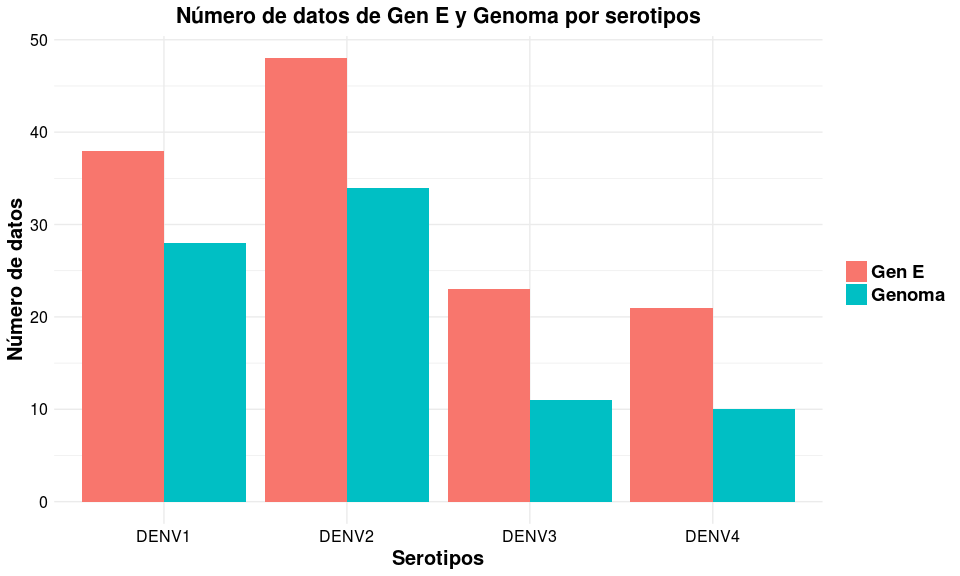

**Número de datos del gen E y del genoma por serotipo.** Obtuvimos 130 datos del Gen E, reportados en 42 países en una escala temporal de 1945 a 2014; y 83 datos del Genoma, reportados en 28 países en una escala temporal de 1944 a 2016. Los datos del gen E y del genoma presentan los cuatro serotipos: serotipo 1 (DENV1) con 38 y 28 casos, el serotipo 2 (DENV2) con 48 y 34 casos, el serotipo 3 (DENV3) con 23 y 11 casos, el serotipo 4 (DENV4) con 21 y 10 casos respectivamente.

## Longitud de las Secuencias seleccionadas

```
[1] "SECUENCIAS GEN E:"
[1] "Longitud maxima:"
[1] 1310
[1] "Longitud mínima:"
[1] 1590
[1] "Longitud media:"
[1] 1485.923
[1] "SECUENCIAS GENOMA:"
[1] "Longitud minima:"
[1] 10176
[1] "Longitud maxima:"
[1] 10736
[1] "Longitud media:"
[1] 10644.64
```

**Gen E** La longitud mínima de las secuencias es 1310 pb, la longitud máxima es 1590 pb y la longitud media es 1486 pb.

## Paises y Localidades

#### Gen E: Paises

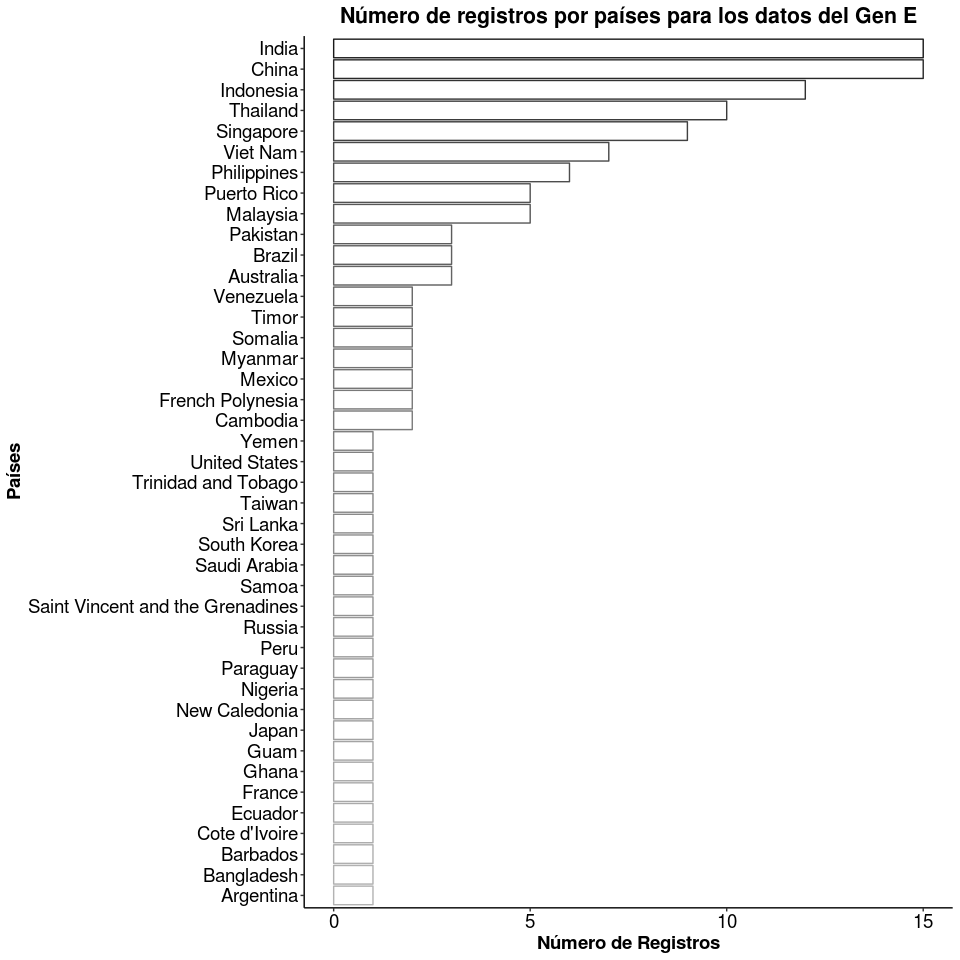

#### Gen E: Localidades

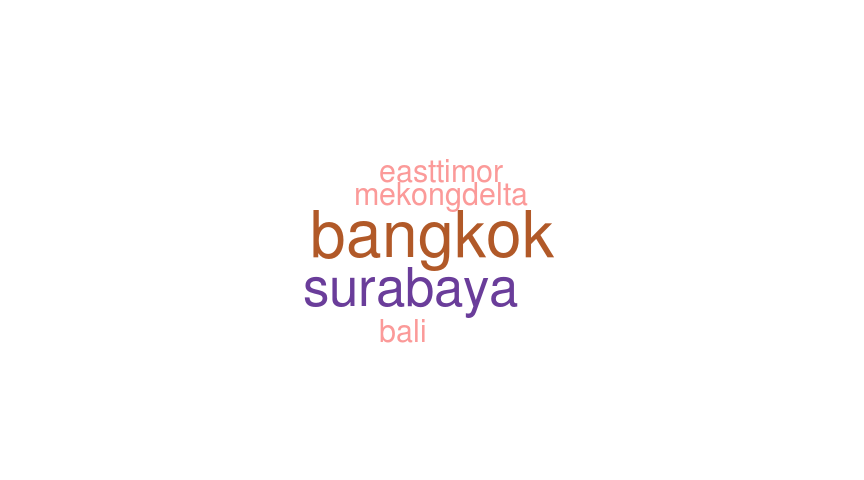

#### Genoma: Paises

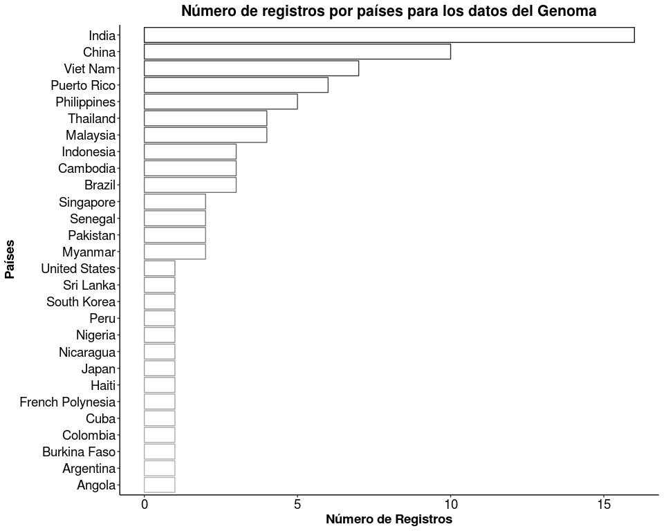

#### Genoma: Localidades

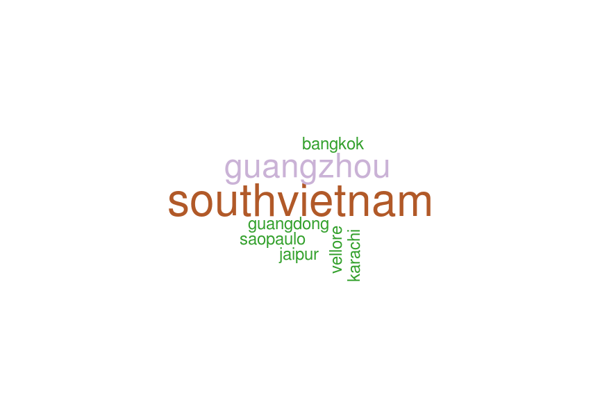

## Años

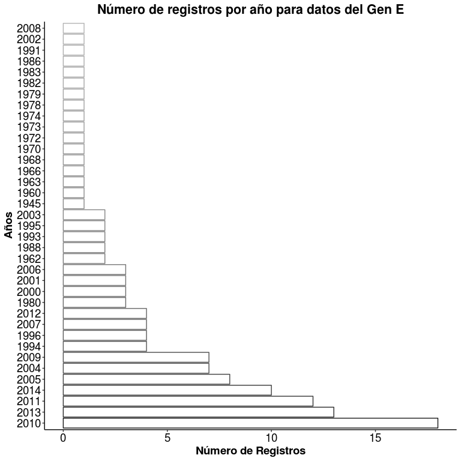

**Años reportados en los datos del gen E** Los datos del Gen E contiene una escala temporal desde el año 1945 a 2014.

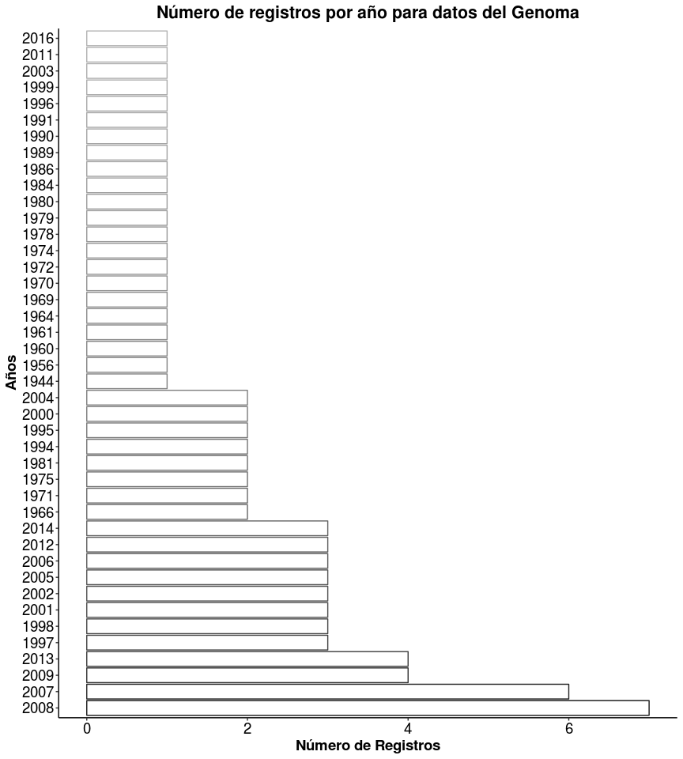

**Años reportados en los datos del genoma** Los datos del Genoma contiene una escala temporal desde el año 1944 a 2016.